# Review and Cleaning of Casco Bay OA Data

# Load Libraries

```r
library(tidyverse)
```

```r
library(readxl)
library(CBEPgraphics)
```

```r
load_cbep_fonts()
```

# Load Data

## Establish Folder References

```r
sibfldnm <- 'Original Data'
parent   <- dirname(getwd())
sibling  <- file.path(parent,sibfldnm)
```

# Load Data

From similar excel spreadsheets.

This code originally generated a lot of warnings because the second row of each spreadsheet contains the units used. Since R is looking for numeric data, it gets confused. There is a solution – to read just the data header from the first file, then read data from all the files skipping the first two rows – but it is simpler to just use “suppressWarnings” to silence the (now expected) warnings. However this suppresses ALL warnings, including new ones that you may need to see. If something is not working, remove the call to suppressWarnings and see if the resulting warnings help identify the problem.

```r
the_data <- list()
for (yr in c(2015, 2016, 2017, 2018)) {
  fn <- paste0('CascoBay_lvl3_',  yr ,'.xls')
  fpath <- file.path(sibling,fn)
  suppressWarnings(df <- read_excel(fpath, col_types = 'numeric',
                   sheet = 'Data')[-1,])  %>%  # dropping garbage second line
  select(- contains('_min')) %>%
  select(- contains('_mean')) %>%
  select(- contains('_max')) %>%
  select(- contains('_std'))
  n <- names(df)
  n <- sub('_median', '', n)
  names(df) <- n
  the_data <- append(the_data, list(df))  #  add dataframe to a list of dataframes.
}
```

# Combine Data

```r
the_data <- bind_rows(the_data) %>%
  select(-yyyymmdd, -Matlab_datenum, -FET_TEMP_CON) %>%
  mutate(datetime = ISOdatetime(yyyy, mm, dd, hh,0,0, 'America/New_York')) %>%
  mutate(doy = as.numeric(strftime(datetime, format = "%j")))
```

In downstream analysis steps, I uncovered duplicate dates and times that lack data, specifically from January of 2016. I filter them out here.

## Demonstrate the Problem

```r
the_data %>% select(datetime) %>% group_by(datetime) %>% summarize(n = n()) %>% filter(n>1) %>% arrange(datetime)
```

| datetime | n |
| --- | --- |
| 2016-01-01 00:00:00 | 2 |
| 2016-01-01 01:00:00 | 2 |
| 2016-01-01 02:00:00 | 2 |
| 2016-01-01 03:00:00 | 2 |
| 2016-01-01 04:00:00 | 2 |
| 2016-01-01 05:00:00 | 2 |
| 2016-01-01 06:00:00 | 2 |
| 2016-01-01 07:00:00 | 2 |
| 2016-01-01 08:00:00 | 2 |
| 2016-01-01 09:00:00 | 2 |

[output cut: 465 more lines]

## Drop any records that have no data

```r
the_data <-  the_data %>% filter(
   ! (
     is.na(SBE37_TEMP) &
     is.na(SBE37_CON) &
     is.na(SBE37_SALINITY) &
     is.na(SAMICO2_TEMP) &
     is.na(SAMI_CO2) &
     is.na(Optode_O2) &
     is.na(FET_PHINT) &
     is.na(FET_PHEXT) &
     is.na(`omega-a`) &
     is.na(`omega-c`) &
     is.na(TA_calc) &
     is.na(DIC_calc)
   )
)
```

# Filtering out Bad PH Data

Larry Harris pointed out that certain pH observations look impossible. Many low pH values look suspect, especially in 2017. In addition, any pH measurements associated with calculated alkalinity below about 1000 should be considered highly suspect, since low alkalinity is unlikely at high salinity.

We explore these problems graphically.

## Graph of pH data over time

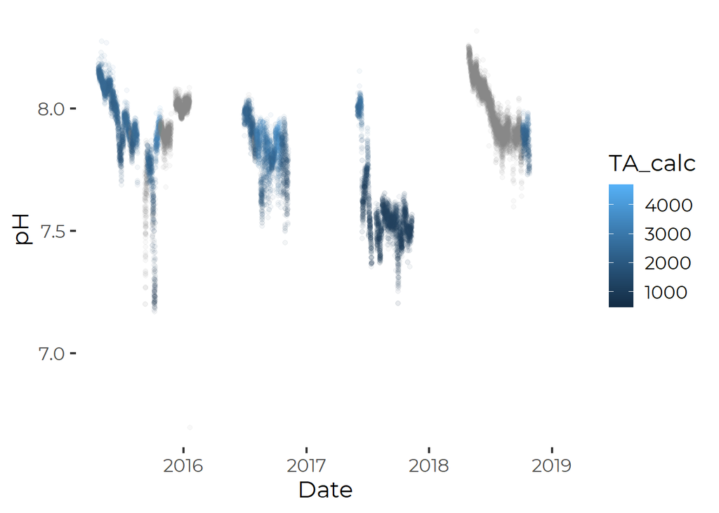

```r
plt <- ggplot(the_data, aes(datetime, FET_PHINT)) +
  geom_point(aes(color = TA_calc), alpha = 0.05) +
  xlab('Date') +
  ylab('pH') +
  theme_cbep()
plt
```

I note low pH excursions in 2015, perhaps 2016, and most of 2017. But note that the fist “spike” of low values in 2015 lack alkalinity calculations, presumably because other required data was not available.

## Graph of pH versus Alkalinity

(Note that since calculated alkalinity is only possible when all other data is available, this graph omits a lot of observations, including some low pH values.)

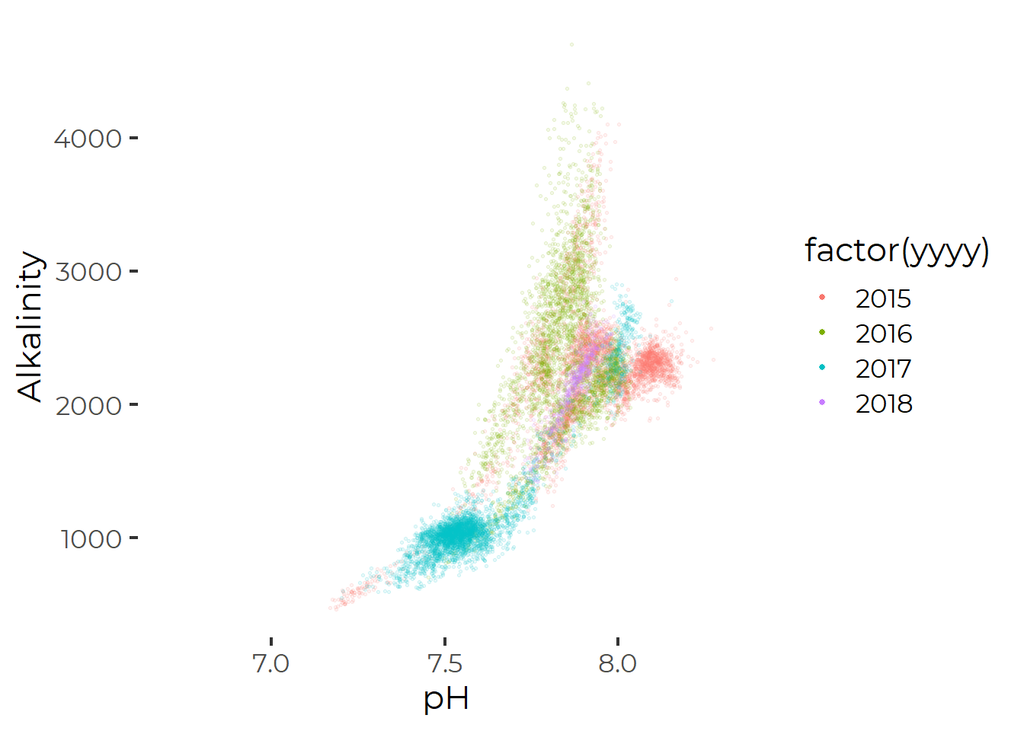

```r
plt <- ggplot(the_data, aes(FET_PHINT, TA_calc, color = factor(yyyy))) +
  geom_point(alpha = 0.1, size = 0.5) +
  xlab('pH') +
  ylab('Alkalinity') +
  theme_cbep() +
   guides(colour = guide_legend(override.aes = list(alpha = 1, size = 1)))
plt
```

The most obvious problematic data (with very low alkalinity AND very low pH) are from 2015 and 2017.

## Graph of Alkalinity vs. Salinity

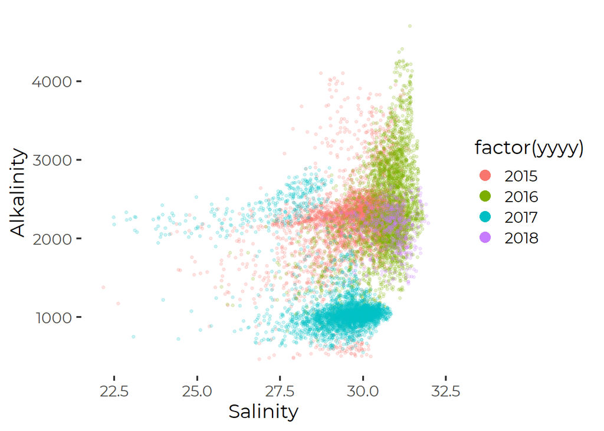

```r
plt <- ggplot(the_data, aes(SBE37_SALINITY, TA_calc, color = factor(yyyy))) +
  geom_point(alpha = 0.2, size = 1)  +
  xlab('Salinity') +
  ylab('Alkalinity') +
  guides(colour = guide_legend(override.aes = list(alpha = 1, size = 4))) +
  scale_x_continuous(limits = c(22,32)) +
  theme_cbep()
plt
```

If we look at a plot of pH versus temperature, the same points jump out, with possibly some other low pH observations from 2016.

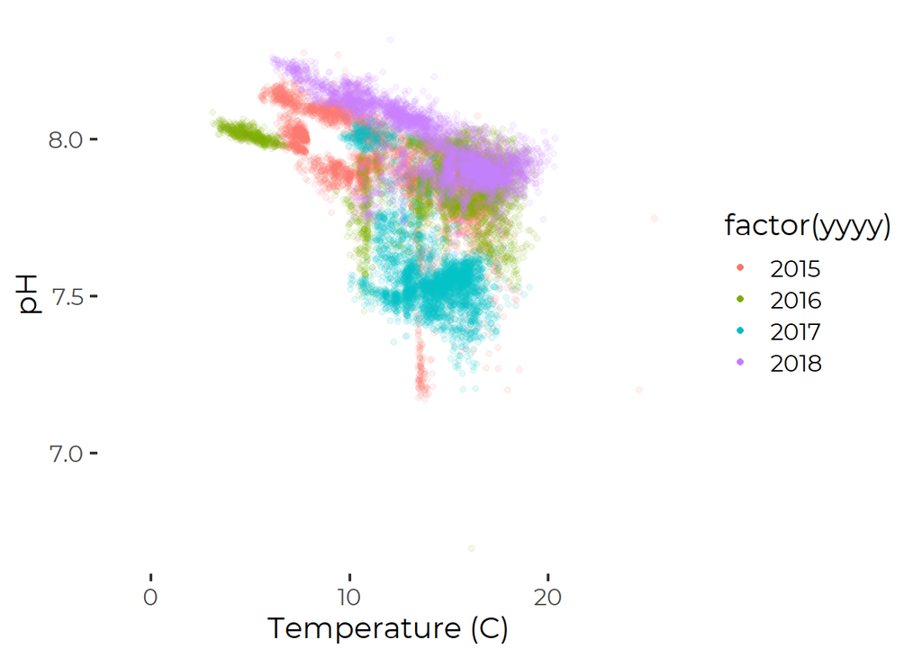

```r
plt <- ggplot(the_data, aes(SBE37_TEMP, FET_PHINT, color = factor(yyyy))) +
  geom_point(alpha = 0.1) +
  theme_cbep() +
  theme(panel.grid.major = element_blank(),
        panel.grid.minor = element_blank()) +
  xlab('Temperature (C)') +
    ylab('pH') +
  guides(colour = guide_legend(override.aes = list(alpha = 1)))
plt
```

I see no obvious way to eliminate the erroneous data. There are “bad” data popping up several times. It’s mostly the 2017 data, but there may also be problematic data in 2015 and 2016.

# Removing Questionable Data

## 2017

Identify the date in 2017 when things went wonky.

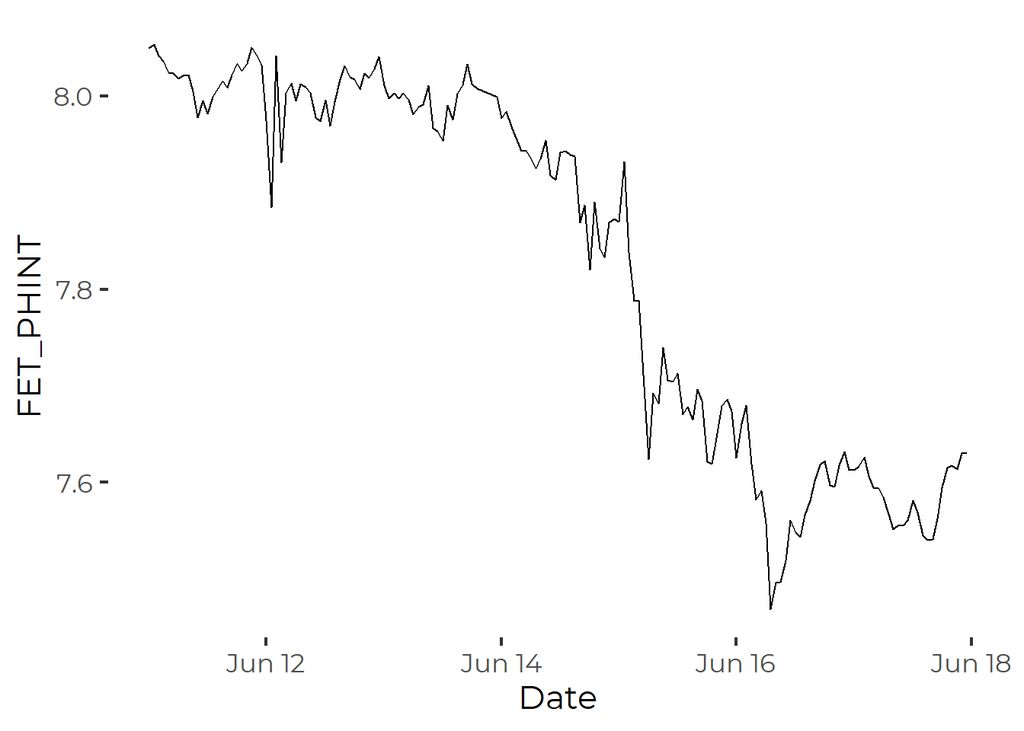

```r
plt <- the_data %>% filter(yyyy==2017, mm == 6, dd<18, dd>10) %>%
  ggplot(aes(x=datetime, y=FET_PHINT)) + geom_line() +
  theme_cbep() +
  xlab('Date')
plt
```

The pH drop off kicks in around June 14th. or 15th.

So, things went odd around June 14th.

# 2015

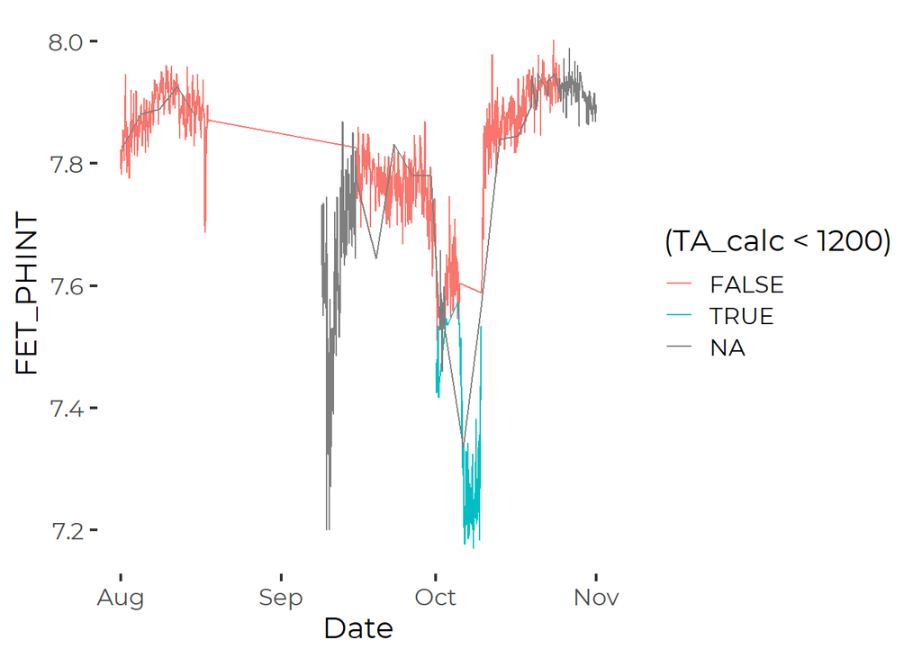

```r
plt <- the_data %>% filter(yyyy==2015, mm %in% c(8,9,10)) %>%
  ggplot(aes(x=datetime, y=FET_PHINT)) +
  geom_line(aes(color=(TA_calc<1200)))+
  theme_cbep() +
  xlab('Date')
plt
```

That shows a low pH period, in September around end of September 8 through Sept 14. That one may actually have started just before the data gap, around August 17th and another around September 30 through October 11. The exact period we should remove from the data here is somewhat arbitrary. Since the primary indicator of problematic data is the low observed pH value, we risk biasing results. Here we back that up by tossing out data by whole days, and by focusing on days with low calculated alkalinity.

# Remove Questionable Data

Remove questionable pH values and ALSO CO2Sys calculated values

```r
d1 <- ISOdatetime(2015,8, 17,0,0, 0,'America/New_York')
d2 <- ISOdatetime(2015,9,14,0,0, 0,'America/New_York')
d3 <- ISOdatetime(2015,9,30,0,0, 0,'America/New_York')
d4 <- ISOdatetime(2015,10,11,0,0, 0,'America/New_York')
d5 <- ISOdatetime(2017,6,14,0,0, 0,'America/New_York')
d6 <- ISOdatetime(2017,12,31,0,0,0,'America/New_York')
phomitflag1  <- ! (the_data$datetime < d1 | the_data$datetime > d2)
phomitflag2  <- ! (the_data$datetime < d3 | the_data$datetime > d4)
phomitflag3  <- ! (the_data$datetime < d5 | the_data$datetime > d6)
flag <- ! (phomitflag1 | phomitflag2 | phomitflag3)
rm(phomitflag1, phomitflag2, phomitflag3)
```

# Show What pH Data Will be Removed

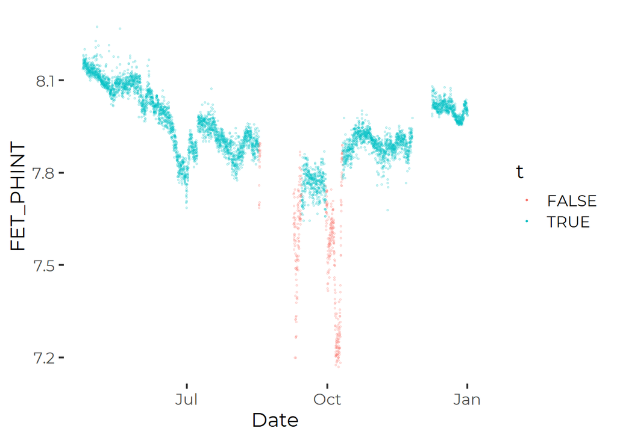

```r
tt <- the_data %>%  mutate(t = flag) %>% filter(yyyy==2015)

plt <- ggplot(tt, aes(x=datetime, y=FET_PHINT)) +
  geom_point(aes(color = t),size = 0.5, alpha = 0.2) +
  theme_cbep() +
  xlab('Date') +
  guides(colour = guide_legend(override.aes = list(alpha = 1)))
plt
```

```r
rm(tt)
```

We are still left with some low values, but the really wonky sudden pH changes are removed.

# Remove Unwanted Data

To trim the data, we use the flags to set to NA any variables that depend on accurate pH values, and then toss out any data that lacks remaining valid observations.

```r
trimmed_data <- the_data %>%
  mutate(FET_PHINT = ifelse(flag, FET_PHINT, NA)) %>%
  mutate(FET_PHEXT = ifelse(flag, FET_PHEXT, NA)) %>%
  mutate(`omega-a` = ifelse(flag, `omega-a`, NA)) %>%
  mutate(`omega-c` = ifelse(flag, `omega-c`, NA)) %>%
  mutate(TA_calc = ifelse(flag, TA_calc, NA)) %>%
  mutate(DIC_calc = ifelse(flag, DIC_calc, NA)) %>%
  filter_all(any_vars(!is.na(.)))
```

# Output Cleaned Data

```r
write_csv(trimmed_data,'CascoBayOAData.csv')
```